# Project 2: Data Mining, Classification, Prediction

SDS322E

# Mining, Classification, Prediction

## Nisha Chowdhary (nac2375)

### Introduction

The data I am using for this project is called candy_rankings, and has to do with candy and its ranking/popularity. The variables include chocolate, fruity, caramel, bar, etc. and are binary variables essentially asking is it chocolate? Fruity? Does it have caramel in it? Etc. Then there are variables such as its sugar percentage (the proportion of sugar it falls under within the data set), its price percentage (the unit price proportion compared to the rest of the set), and its win percent (the overall win percentage according to 269,000 match ups.) I am going to use this data to determine what types of candy the people enjoy most and what they think makes for a “good” piece of candy.

```r
library(tidyverse)
library(fivethirtyeight)
candy <- candy_rankings
```

### Cluster Analysis

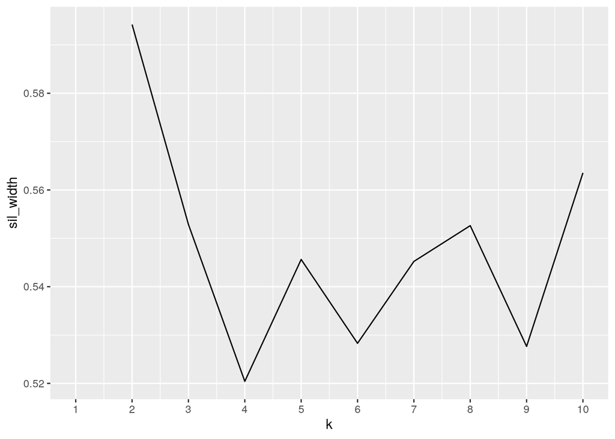

```r
candy_numeric <- candy %>% select_if(is.numeric)
library(cluster)
sil_width <- vector()
for (i in 2:10) {
    kms <- kmeans(candy_numeric, centers = i)
    sil <- silhouette(kms$cluster, dist(candy_numeric))
    sil_width[i] <- mean(sil[, 3])
}
ggplot() + geom_line(aes(x = 1:10, y = sil_width)) + scale_x_continuous(name = "k",
    breaks = 1:10)
```

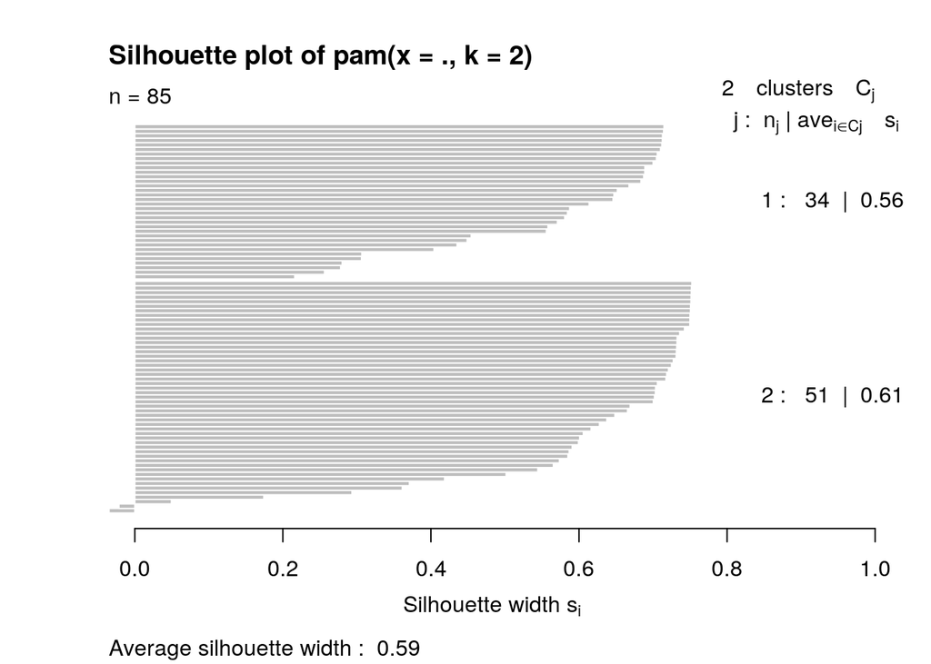

```r
candy_pam <- candy_numeric %>% pam(k = 2)
plot(candy_pam, which = 2)
```

```r
candy_pam1 <- candy_numeric %>% scale %>% pam(k = 2)
candy_pam1
```

```
## Medoids:
##      ID sugarpercent pricepercent winpercent
## [1,] 66    0.4432911    0.6373553  0.6260883
## [2,] 84   -1.0349008   -0.7065256 -0.5717175
## Clustering vector:
##  [1] 1 1 2 2 1 1 1 2 1 2 1 1 2 1 2 2 1 1 1 2 1 2 2 1 1 1 2 2 1 2 2 2 1 1 1 1 1 1
## [39] 1 1 1 1 1 1 2 2 1 1 2 1 2 2 1 1 1 1 1 2 1 2 1 1 1 2 1 1 2 2 2 2 1 2 2 1 1 2
## [77] 2 2 2 1 2 2 2 2 1
## Objective function:
##    build     swap
## 1.367592 1.255399
##
## Available components:
##  [1] "medoids"    "id.med"     "clustering" "objective"  "isolation"
##  [6] "clusinfo"   "silinfo"    "diss"       "call"       "data"
```

The cluster solution (I chose two clusters because it had the highest silhouette width of 0.59) looks like a reasonable structure for this data. The two candies that are the medoids are Snickers Crisper (ID 66) and Werther’s Original Caramel (ID 84). It looks like they are somewhat different on all three of the variables.

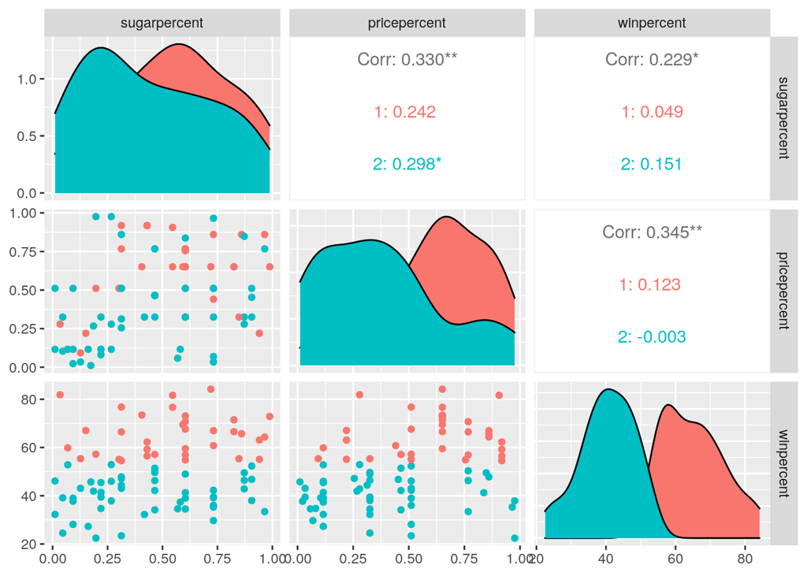

```r
library(GGally)
final <- candy_numeric %>% mutate(cluster = as.factor(candy_pam$clustering))
final %>% ggpairs(columns = 1:3, aes(color = cluster))
```

The variable that shows the greatest difference between clusters is the “winpercent” and the variable that is most similar between the two clusters is “sugarpercent”. Cluster one appears to have a higher percentage, on average, for each of the three variables.

### Dimensionality Reduction with PCA

```r
pca1 <- princomp(candy_numeric, cor = T)
eigval <- pca1$sdev^2
round(cumsum(eigval)/sum(eigval), 2)
```

```
## Comp.1 Comp.2 Comp.3
##   0.54   0.79   1.00
```

```r
summary(pca1, loadings = T)
```

```
## Importance of components:
##                           Comp.1    Comp.2    Comp.3
## Standard deviation     1.2670871 0.8782385 0.7894222
## Proportion of Variance 0.5351699 0.2571010 0.2077292
## Cumulative Proportion  0.5351699 0.7922708 1.0000000
##
## Loadings:
##              Comp.1 Comp.2 Comp.3
## sugarpercent  0.549  0.736  0.395
## pricepercent  0.619        -0.784
## winpercent    0.561 -0.676  0.478
```

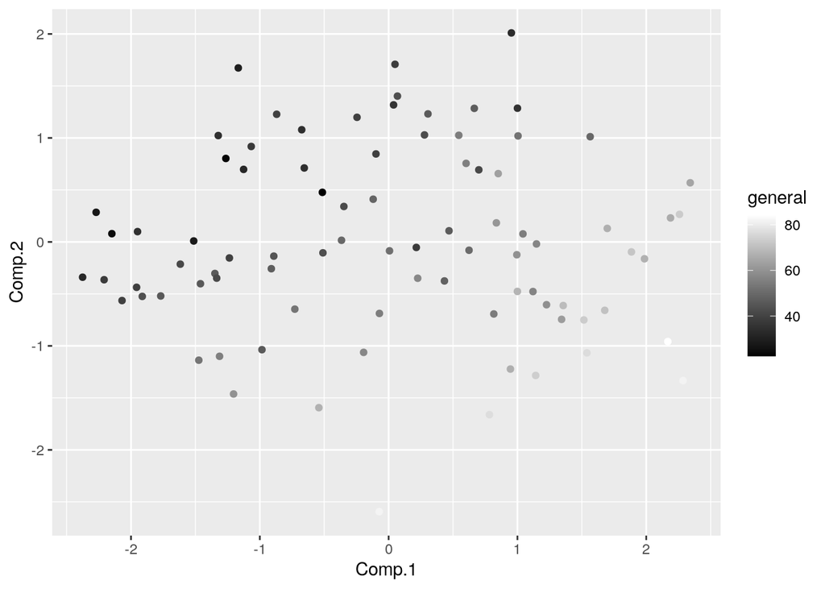

```r
data <- as.data.frame(pca1$scores) %>% mutate(general = candy_numeric$winpercent)
data %>% ggplot(aes(Comp.1, Comp.2, color = general)) + geom_point() +
    scale_colour_gradient(low = "black", high = "white")
```

```r
cor(data$general, data$Comp.1)
```

```
## [1] 0.7108833
```

```r
cor(data$general, data$Comp.2)
```

```
## [1] -0.5933763
```

PC1 makes up 54 percent of the total variance. PC1 and PC2 make up 79% of the total variance. For each column if a variable is positive and another variable is negative then those are inversely correlated, so if the percent is high for one, then the other one would most likely have a low percentage and vice versa. For example, for PC3 if you score well on it, it’s likely that if the win percent is high then the price percent is low. For PC2 if the sugar percent is high then the win percent is more likely to be low. Additionally, from the graph we can see that there is a semi-strong positive correlation between win percent and score of PC1 (0.71). There is a little negative correlation between win percent and PC2 (-0.5933).

### Linear Classifier

```r
# linear classifier code here
fit <- glm(chocolate == "TRUE" ~ sugarpercent + pricepercent +
    winpercent, data = candy, family = "binomial")
prob_reg <- predict(fit)
class_diag(prob_reg, candy$chocolate, positive = "TRUE")
```

```
##            acc   sens   spec    ppv     f1     ba    auc
## Metrics 0.8588 0.7568 0.9375 0.9032 0.8235 0.8471 0.9105
```

```r
# confusion matrix
table(truth = factor(candy$chocolate == "TRUE", levels = c("TRUE",
    "FALSE")), prediction = factor(prob_reg[] > 0.5, levels = c("TRUE",
    "FALSE"))) %>% addmargins
```

```
##        prediction
## truth   TRUE FALSE Sum
##   TRUE    28     9  37
##   FALSE    3    45  48
##   Sum     31    54  85
```

I used a logistic regression fit for this section to see how well we can predict weather a candy contains chocolate or not based on all the numeric variables. With an AUC of 0.9105, the model is performing rather well for all the observations. From the confusion matrix, we can see that there is a true positive rate of 0.757, a true negative rate of 0.9375, and a positive predictive value of 0.903.

```r
set.seed(322)
k = 10

data <- sample_frac(candy)  #randomly order rows
folds <- rep(1:k, length.out = nrow(data))  #create folds

diags <- NULL

i = 1
for (i in 1:k) {
    # create training and test sets
    train <- data[folds != i, ]
    test <- data[folds == i, ]
    truth <- test$chocolate

    # train model
    fit <- glm(chocolate == "TRUE" ~ sugarpercent + pricepercent +
        winpercent, data = train, family = "binomial")  ### SPECIFY THE LOGISTIC REGRESSION MODEL FIT TO THE TRAINING SET HERE

    # test model
    probs <- predict(fit, newdata = test, type = "response")  ### GET PREDICTIONS FROM THE TRAINED MODEL ON THE TEST SET HERE

    # get performance metrics for each fold
    diags <- rbind(diags, class_diag(probs, truth, positive = "TRUE"))
}

# average performance metrics across all folds
summarize_all(diags, mean)
```

```
##       acc    sens    spec  ppv      f1     ba     auc
## 1 0.84723 0.81834 0.89547 0.87 0.80983 0.8569 0.93286
```

We can see that the AUC has gone up 0.9105 to 0.9329, which means that there are not signs of over-fitting and the model is predicting new observations well.

### Non-Parametric Classifier

```r
library(caret)
knn_fit <- knn3(factor(chocolate == "TRUE", levels = c("TRUE",
    "FALSE")) ~ candy$sugarpercent + candy$pricepercent + candy$winpercent,
    k = 5, data = candy)
y_hat_knn <- predict(knn_fit, candy)
class_diag(y_hat_knn[, 1], candy$chocolate, positive = "TRUE")
```

```
##            acc   sens   spec    ppv     f1     ba    auc
## Metrics 0.8588 0.7838 0.9167 0.8788 0.8286 0.8502 0.9223
```

```r
# confusion matrix
table(truth = factor(candy$chocolate == "TRUE", levels = c("TRUE",
    "FALSE")), prediction = factor(y_hat_knn[, 1] > 0.5, levels = c("TRUE",
    "FALSE"))) %>% addmargins
```

```
##        prediction
## truth   TRUE FALSE Sum
##   TRUE    29     8  37
##   FALSE    4    44  48
##   Sum     33    52  85
```

From the confusion matrix we can see that with a knn model there is a predicted positive rate of 0.8788 (also seen from the class_diag function). The AUC is 0.9223 which means the model is performing well.

```r
set.seed(322)
k = 10

data <- sample_frac(candy)  #randomly order rows
folds <- rep(1:k, length.out = nrow(data))  #create folds

diags <- NULL

i = 1
for (i in 1:k) {
    # create training and test sets
    train <- data[folds != i, ]
    test <- data[folds == i, ]
    truth <- test$chocolate

    # train model
    fit <- knn3(chocolate == "TRUE" ~ sugarpercent + pricepercent +
        winpercent, data = train, )
    # test model
    probs <- predict(fit, newdata = test)[, 2]

    # get performance metrics for each fold
    diags <- rbind(diags, class_diag(probs, truth, positive = "TRUE"))
}

# average performance metrics across all folds
summarize_all(diags, mean)
```

```
##       acc    sens   spec  ppv      f1     ba     auc
## 1 0.83473 0.82834 0.8781 0.85 0.80405 0.8532 0.86056
```

Unfortunately, the AUC has gone down, which means that the model is not doing as good of a job at predicting if a candy is chocolate or not for new samples. This also implies that there are signs of over-fitting. Clearly, the linear model does a better job than the non-parametric model in its cross-validation performance.

### Regression/Numeric Prediction

```r
fit <- lm(winpercent ~ -competitorname, data = candy)
yhat <- predict(fit)
mean((candy$winpercent - yhat)^2)  #mean squared error (MSE)
```

```
## [1] 213.9651
```

```r
library(dplyr)
set.seed(1234)
k = 5  #choose number of folds
data <- sample_frac(candy %>% select(-competitorname))  #randomly order rows
folds <- rep(1:k, length.out = nrow(data))  #create folds
diags <- NULL
for (i in 1:k) {
    train <- data[folds != i, ]
    test <- data[folds == i, ]
    ## Fit linear regression model to training set
    fit <- lm(winpercent ~ ., data = train)
    ## Get predictions/y-hats on test set (fold i)
    yhat <- predict(fit, newdata = test)
    ## Compute prediction error (MSE) for fold i
    diags <- mean((test$winpercent - yhat)^2)
}
mean(diags)
```

```
## [1] 171.0952
```

### Python

```python
import numpy as np
candy = r.candy
np.mean(candy['winpercent'])
```

```
## 50.316763811764716
```

```python
max(candy['winpercent']) #recess peanut butter cup (also my favorite!)
```

```
## 84.18029
```

```python
sugar = candy['sugarpercent']
win = candy['winpercent']
name = candy['competitorname']
```

I accessed the dataset from r using the r. function. Then I calculated the average win percentage for the entire dataset which resulted in a value of about 50.3. Next, I found the maximum win percentage which was around 84.18 percent. Finally I created vectors to access and use in the next part for the variables “sugarpercent”, “winpercent”, and “competitorname”.

```r
library(reticulate)
sugar_name <- data.frame(sugar = py$sugar, name = py$name, win = py$win)
glimpse(sugar_name %>% arrange(-sugar))
```

```
## Rows: 85
## Columns: 3
## $ sugar <dbl> 0.988, 0.965, 0.965, 0.941, 0.941, 0.906, 0.906, 0.906, 0.872, …
## $ name  <fct> Reese's stuffed with pieces, Milky Way Simply Caramel, Sugar Ba…
## $ win   <dbl> 72.88790, 64.35334, 33.43755, 63.08514, 55.10370, 52.34146, 38.…
```

I created a mini dataset for the three variables I created in python to access in the R portion. I wanted to see what the highest proportion of sugar for the dataset was and what its win percentage was. Interestingly enough, the highest sugar proportion was Reese’s stuffed with pieces with a win percentage of 72.8879, which is fairly higher than the average win percentage calculated in the above part.

### Concluding Remarks

If I were to continue analyzing this data I would want to explore the relationship between win percentage and the other categorical variables individually a bit more.